# 04 dataset visualizations

2025-04-12

```r
data04 <- read_csv("YEAR-04-DATA-PUF.csv")
```

## CEO race data - Pie chart

The majority of nonprofit CEOs are White, with 75% of the organizations reporting White CEOs. This seems to be a statistic that is representative of the US population, as 75.3% of Americans identify as white (https://www.census.gov/quickfacts/fact/table/US/PST045224)

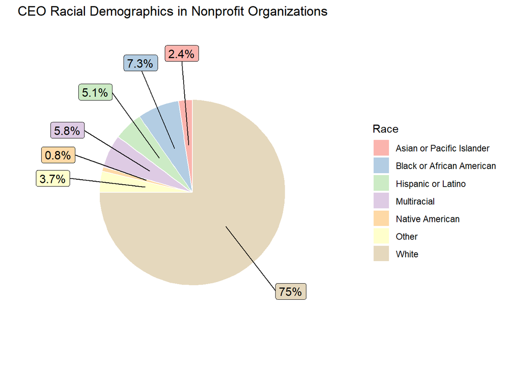

```r
race_labels <- c(
  "1" = "Asian or Pacific Islander",
  "2" = "Black or African American",
  "3" = "Hispanic or Latino",
  "4" = "Native American",
  "5" = "White",
  "6" = "Multiracial",
  "7" = "Other"
)


data04 <- data04 |>
  filter(!is.na(CEOrace)) |>
  mutate(ceo_race_label = recode(as.character(CEOrace), !!!race_labels))

#percentages

race_counts <- data04 |>
  count(ceo_race_label) |>
  mutate(perc = n / sum(n) * 100,
         label = paste0(ceo_race_label, ": ", round(perc, 1), "%"))

# Adjusting label positions
df2 <- race_counts |>
  mutate(csum = rev(cumsum(rev(perc))),
         pos = perc / 2 + lead(csum, 1),
         pos = if_else(is.na(pos), perc / 2, pos))

# pie chart with softer colors, label adjustments, and new legend title
ggplot(race_counts, aes(x = "", y = perc, fill = ceo_race_label)) +
  geom_bar(stat = "identity", width = 1, color = "white") +
  coord_polar(theta = "y") +
  labs(title = "CEO Racial Demographics in Nonprofit Organizations",
       fill = "Race") +  # Change legend title to "Race"
  theme_void() +
  geom_label_repel(data = df2,
                   aes(y = pos, label = paste0(round(perc, 1), "%")),
                   size = 4,
                   nudge_x = 1,
                   show.legend = FALSE) +
  scale_fill_brewer(palette = "Pastel1")  # Softer color palette
```

## CEO gender data- Pie chart

The high proportion of female CEOs could reflect broader trends in nonprofit sectors that are often seen as more women-focused, especially in fields like Human Services and Education. (Something to do additional searching on!)

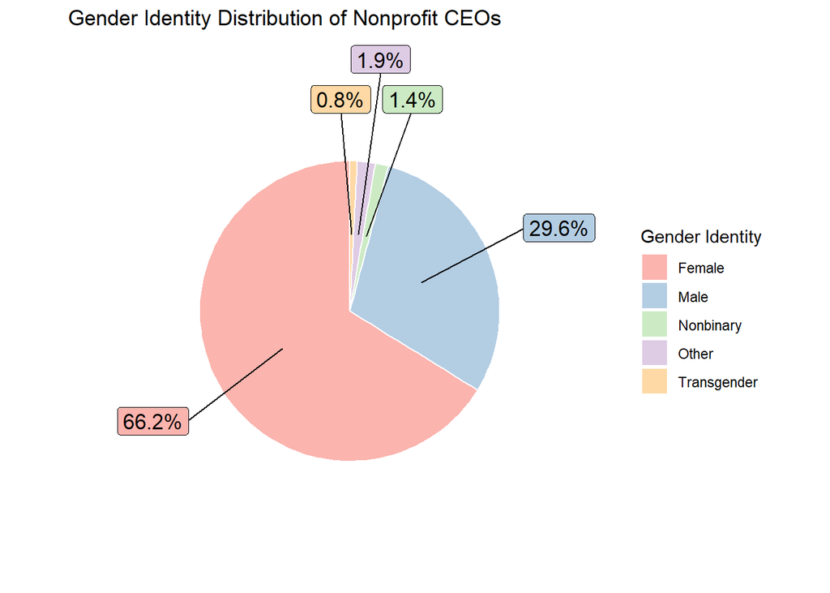

```r
df_gender <- data04 |>
  select(CEOgender_Man, CEOgender_Woman, CEOgender_Trans,
         CEOgender_NB, CEOgender_Oth)

df_gender_long <- df_gender |>
  pivot_longer(cols = everything(), names_to = "gender_column", values_to = "gender_value")

df_gender_long1 <- df_gender_long |>
  filter(gender_value == "1")

df_gender_long2 <- df_gender_long1 |>
  mutate(gender_value = case_when(
    gender_column == "CEOgender_Man" ~ "Male",
    gender_column == "CEOgender_Woman" ~ "Female",
    gender_column == "CEOgender_Trans" ~ "Transgender",
    gender_column == "CEOgender_NB" ~ "Nonbinary",
    gender_column == "CEOgender_Oth" ~ "Other",
    TRUE ~ NA_character_
  ))

gender_counts <- df_gender_long2 |>
  count(gender_value, name = "count") |>
  mutate(percentage = count / sum(count) * 100)

# label positions
df2 <- gender_counts |>
  mutate(csum = rev(cumsum(rev(percentage))),
         pos = percentage / 2 + lead(csum, 1),
         pos = if_else(is.na(pos), percentage / 2, pos))


ggplot(gender_counts, aes(x = "", y = percentage, fill = gender_value)) +
  geom_bar(stat = "identity", width = 1, color = "white") +
  coord_polar(theta = "y") +
  theme_void() +
  labs(title = "Gender Identity Distribution of Nonprofit CEOs",
       fill = "Gender Identity") +  # Change legend title here
  geom_label_repel(data = df2,
                   aes(y = pos, label = paste0(round(percentage, 1), "%")),
                   size = 4.5,
                   nudge_x = 1,
                   show.legend = FALSE) +
  scale_fill_brewer(palette = "Pastel1") # Optional: Change color palette
```

## Most Common Revenue Sources - bar chart

The primary source of revenue is Donations from Individuals, followed by Grants.

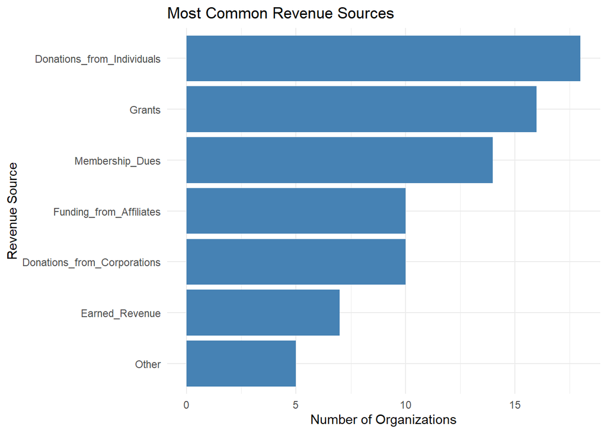

```r
data04 |>
  summarise(
    Donations_from_Individuals = sum(Affiliation_Members_IndivDon, na.rm = TRUE),
    Donations_from_Corporations = sum(Affiliation_Members_CorpDon, na.rm = TRUE),
    Grants = sum(Affiliation_Members_Grants, na.rm = TRUE),
    Earned_Revenue = sum(Affiliation_Members_EarnedRev, na.rm = TRUE),
    Membership_Dues = sum(Affiliation_Members_Dues, na.rm = TRUE),
    Funding_from_Affiliates = sum(Affiliation_Members_Affiliated, na.rm = TRUE),
    Other = sum(Affiliation_Members_Other, na.rm = TRUE)
  ) |>
  pivot_longer(everything(), names_to = "Revenue_Source", values_to = "Count") |>
  ggplot(aes(x = reorder(Revenue_Source, Count), y = Count)) +
  geom_col(fill = "steelblue") +
  coord_flip() +
  labs(title = "Most Common Revenue Sources",
       x = "Revenue Source",
       y = "Number of Organizations") +
  theme_minimal()
```

## Revenue Source Distribution - pie chart

Continuation of what we see above: Donations from Individuals contribute to 22.5% of the revenue, followed by Grants (20%) and Membership Dues (17.5%).

This suggests that these organizations are primarily funded through a combination of donations and grant funding. This indicates that nonprofits have a strong reliance on individuals to support them.

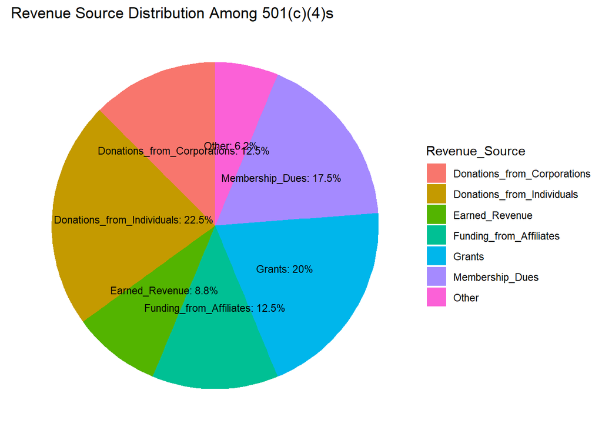

```r
data04 |>
  summarise(
    Donations_from_Individuals = sum(Affiliation_Members_IndivDon, na.rm = TRUE),
    Donations_from_Corporations = sum(Affiliation_Members_CorpDon, na.rm = TRUE),
    Grants = sum(Affiliation_Members_Grants, na.rm = TRUE),
    Earned_Revenue = sum(Affiliation_Members_EarnedRev, na.rm = TRUE),
    Membership_Dues = sum(Affiliation_Members_Dues, na.rm = TRUE),
    Funding_from_Affiliates = sum(Affiliation_Members_Affiliated, na.rm = TRUE),
    Other = sum(Affiliation_Members_Other, na.rm = TRUE)
  ) |>
  pivot_longer(everything(), names_to = "Revenue_Source", values_to = "Count") |>
  mutate(Percentage = Count / sum(Count) * 100,
         Label = paste0(Revenue_Source, ": ", round(Percentage, 1), "%")) |>
  ggplot(aes(x = "", y = Count, fill = Revenue_Source)) +
  geom_col(width = 1) +
  coord_polar("y") +
  theme_void() +
  geom_text(aes(label = Label),
            position = position_stack(vjust = 0.5), size = 3) +
  labs(title = "Revenue Source Distribution Among 501(c)(4)s")
```

## Percent of Nonprofits Receiving Government Grants/Contracts - bar chart

This graph shows the percentage of nonprofit organizations that receive funding from the local, state, and federal governments. As we can see, local government is the most common source of government support, with more than 50% of organizations receiving funding at this level. State government grants come second, followed by federal grants.

It’s important to note that these percentages reflect the average proportion of organizations within the dataset that receive funding at each level, not a sum of total funding across all levels. This suggests that many nonprofits rely heavily on local government support, particularly for sectors that provide community-based services.

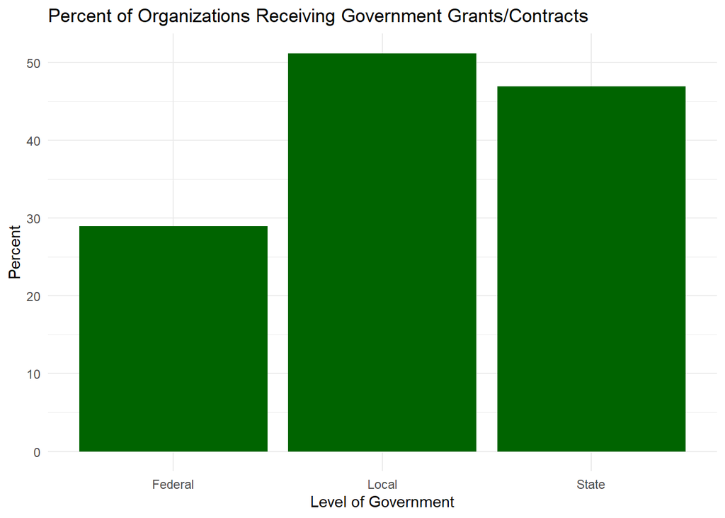

```r
data04 |>
  summarise(
    Local = mean(LocalGov, na.rm = TRUE) * 100,
    State = mean(StateGov, na.rm = TRUE) * 100,
    Federal = mean(FederalGov, na.rm = TRUE) * 100
  ) |>
  pivot_longer(everything(), names_to = "GovLevel", values_to = "Proportion") |>
  ggplot(aes(x = GovLevel, y = Proportion)) +
  geom_col(fill = "darkgreen") +
  labs(title = "Percent of Organizations Receiving Government Grants/Contracts",
       x = "Level of Government",
       y = "Percent") +
  theme_minimal()
```

## Largest Source of Revenue - Bar Chart

We see that private funding is the largest source of revenue. This could be true because smaller nonprofits or those focused on niche services are more likely to be funded privately.

Although less dominant, government agencies also represent a significant source of revenue. This could be true for larger organizations that are involved in advocacy that aligns with government priorities.

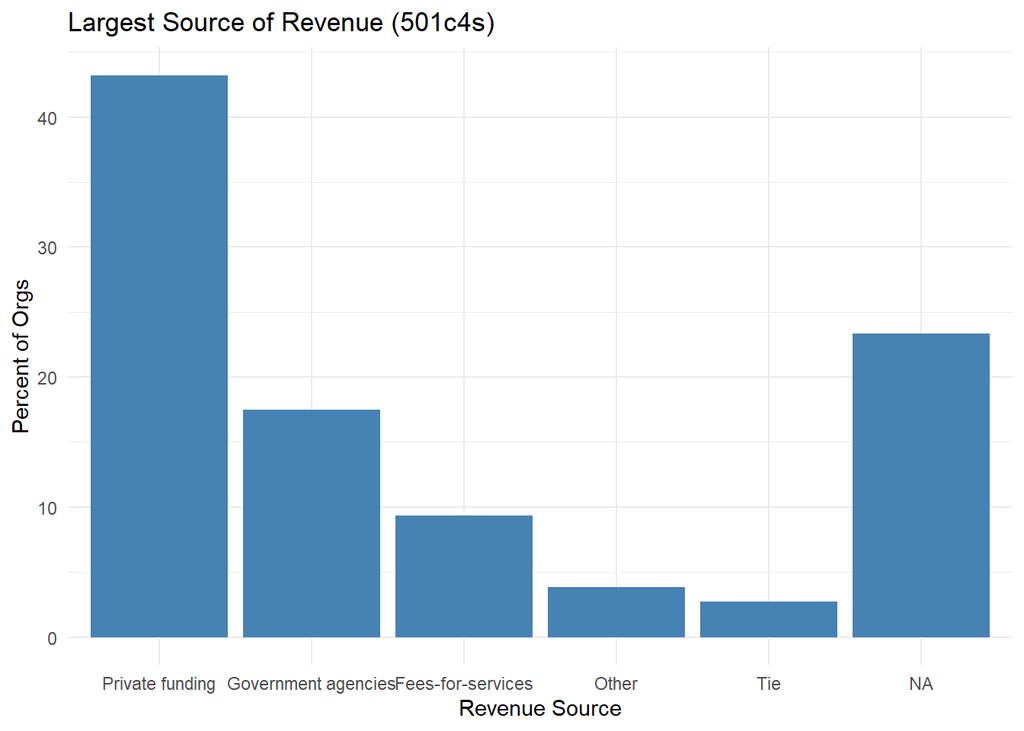

```r
data04 |>
  count(LargestRev) |>
  mutate(Percentage = n / sum(n) * 100) |>
  ggplot(aes(x = reorder(LargestRev, -Percentage), y = Percentage)) +
  geom_col(fill = "steelblue") +
  labs(title = "Largest Source of Revenue (501c4s)",
       x = "Revenue Source",
       y = "Percent of Orgs") +
  theme_minimal()
```

## Government Support by Primary Revenue Source - bar chart

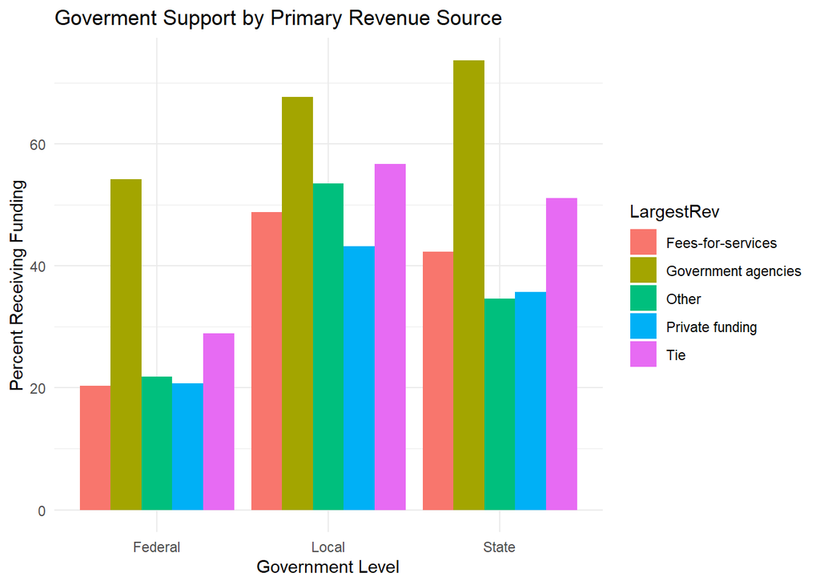

```r
# graph 1 shows the types of government support.
data04 |>
  filter(!is.na(LargestRev)) |>
  group_by(LargestRev) |>
  summarise(
    Local = mean(LocalGov, na.rm = TRUE),
    State = mean(StateGov, na.rm = TRUE),
    Federal = mean(FederalGov, na.rm = TRUE)
  ) |>
  pivot_longer(-LargestRev, names_to = "GovLevel", values_to = "Proportion") |>
  ggplot(aes(x = GovLevel, y = Proportion * 100, fill = LargestRev)) +
  geom_col(position = "dodge") +
  labs(title = "Goverment Support by Primary Revenue Source",
       y = "Percent Receiving Funding",
       x = "Government Level") +
  theme_minimal()
```

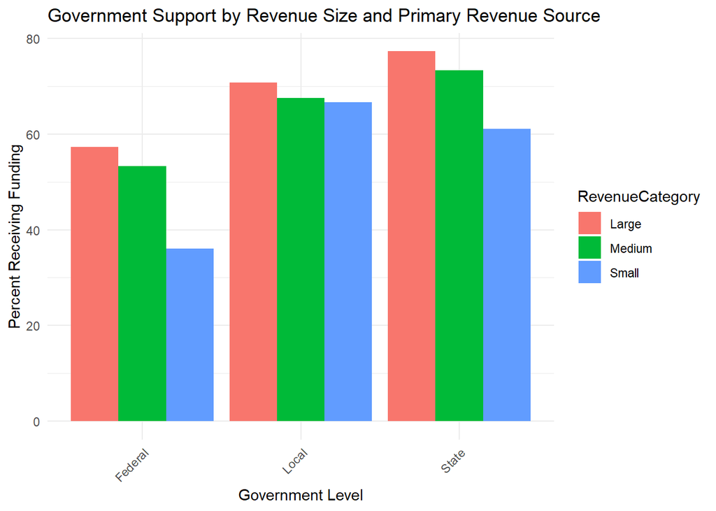

```r
## Graph 2 shows us clear trends- large nonprofits receive highest % of government support at all levels (local, state, federal)


data04 |>
  filter(!is.na(LargestRev), !is.na(TotRev_clean_nozero)) |>
  mutate(


# To categorize nonprofits by revenue size
    RevenueCategory = case_when(
      TotRev_clean_nozero < 100000 ~ "Small",
      TotRev_clean_nozero >= 100000 & TotRev_clean_nozero < 1000000 ~ "Medium",
      TotRev_clean_nozero >= 1000000 ~ "Large"
    )
  ) |>
  group_by(RevenueCategory, LargestRev) |>
  summarise(


# To calculate the average proportion of government funding by level


    Local = mean(LocalGov, na.rm = TRUE),
    State = mean(StateGov, na.rm = TRUE),
    Federal = mean(FederalGov, na.rm = TRUE),
    .groups = "drop"

# Drop grouping after summarizing

  ) |>
  pivot_longer(cols = c(Local, State, Federal), names_to = "GovLevel", values_to = "Proportion") |>
  ggplot(aes(x = GovLevel, y = Proportion * 100, fill = RevenueCategory)) +
  geom_col(position = "dodge") +
  labs(
    title = "Government Support by Revenue Size and Primary Revenue Source",
    y = "Percent Receiving Funding",
    x = "Government Level"
  ) +
  theme_minimal() +
  theme(
    axis.text.x = element_text(angle = 45, hjust = 1)
  )
```

```r
data04 |>
  mutate(GovSupport = pmax(LocalGov, StateGov, FederalGov, na.rm = TRUE)) |>
  group_by(LargestRev) |>
  summarise(Percent_with_GovSupport = mean(GovSupport, na.rm = TRUE) * 100)
```

```
## # A tibble: 6 × 2
##   LargestRev          Percent_with_GovSupport
##   <chr>                                 <dbl>
## 1 Fees-for-services                      65.8
## 2 Government agencies                    94.1
## 3 Other                                  68.3
## 4 Private funding                        56.2
## 5 Tie                                    72.2
## 6 <NA>                                   71.0
```

## Proportion of Total Fundraising Expenses by group

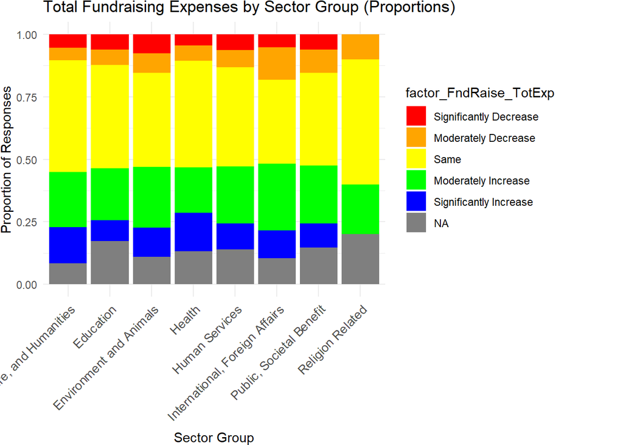

```r
# Clean the data: Convert 97 and 98 to NA, and convert to factor
data04_cleaned <- data04 |>
  mutate(across(contains("FndRaise_"), ~na_if(., 97), .names = "cleaned_{col}")) |>
  mutate(across(contains("FndRaise_"), ~na_if(., 98), .names = "cleaned_{col}")) |>
  mutate(across(contains("FndRaise_"), as.factor, .names = "factor_{col}"))

# Step 1: Re-code sector codes to broader groups

data04_cleaned$sector_group <- recode(data04_cleaned$ntee1,
                                      A = "I.", B = "II.", C = "III.", D = "III.",
                                      E = "IV.", F = "IV.", G = "IV.", H = "IV.",
                                      I = "V.", J = "V.", K = "V.", L = "V.",
                                      M = "V.", N = "V.", O = "V.", P = "V.",
                                      Q = "VI.", R = "VII.", S = "VII.", T = "VII.",
                                      U = "VII.", V = "VII.", W = "VII.",
                                      X = "VIII.", Y = "IX.", Z = "X.")



# Step 2: Handle any missing or invalid values in sector_group (if needed)
data04_cleaned$sector_group <- ifelse(is.na(data04_cleaned$sector_group), "Unknown", data04_cleaned$sector_group)



# Step 3: Convert FndRaise_TotExp into a factor for visualization
data04_cleaned$factor_FndRaise_TotExp <- factor(data04_cleaned$FndRaise_TotExp,
                                                 levels = c(1, 2, 3, 4, 5),
                                                 labels = c("Significantly Decrease", "Moderately Decrease", "Same",
                                                            "Moderately Increase", "Significantly Increase"))

# Step 4: Define sector labels for x-axis (Roman numerals with full descriptions)
sector_labels <- c(
  "I." = "Arts, Culture, and Humanities",
  "II." = "Education",
  "III." = "Environment and Animals",
  "IV." = "Health",
  "V." = "Human Services",
  "VI." = "International, Foreign Affairs",
  "VII." = "Public, Societal Benefit",
  "VIII." = "Religion Related",
  "IX." = "Mutual/Membership Benefit",
  "X." = "Unknown, Unclassified"
)

# Create the plot
ggplot(data04_cleaned, aes(x = sector_group, fill = factor_FndRaise_TotExp)) +
  geom_bar(position = "fill") +
  labs(title = "Total Fundraising Expenses by Sector Group (Proportions)",
       x = "Sector Group", y = "Proportion of Responses") +
  scale_fill_manual(values = c("red", "orange", "yellow", "green", "blue", "gray"),
                    labels = c("Significantly Decrease", "Moderately Decrease", "Same", "Moderately Increase", "Significantly Increase", "NA")) +
  scale_x_discrete(labels = sector_labels) +  # Use Roman numerals with full descriptions
  theme_minimal() +
  theme(
    axis.text.x = element_text(angle = 45, hjust = 1, size = 10),  # Rotate labels for readability
    plot.margin = margin(r = 50)  # Increase right margin for label spacing
  )
```